# PBHLTH W251 Milestone 6

Priya Bala and Mihir Pandya

2023-12-10

# Age-Specific Dynamics of Flu Cases and COVID-19 Vaccination in Alameda County

## Problem Statement

In recent years, given the pandemic of COVID-19, vaccination rates against the virus have risen since the introduction of COVID-19 vaccines at the end of calendar year 2020. This is true for the state of California, where vaccination data across all of the state’s 58 counties (stratified by age) can be used for infectious diseases surveillance by the California Department of Public Health. Specifically, analysis of the aforementioned data could reveal if COVID-19 vaccination rates have any impact on flu vaccination rates/cases and severity. This can be done by examining data for flu cases and severity across the entire state stratified by demographic categories (age/race/sex), including in the states largest county, Los Angeles.

## Methods

The three aforementioned data sources used as the basis for this analysis between COVID-19 vaccination rates and those for the flu are the following: weekly data for flu cases and severity by demographic (age/race/sex) categories across all California counties except Los Angeles (sim_flu_CA.csv), similar data as sim_flu_CA.csv except just for Los Angeles County (sim_flu_LACounty.csv), and quarterly COVID-19 vaccination data by age for all of California’s 58 counties (ca_vax_rates_quarter.csv). Both the sim_flu_CA.csv and sim_flu_LACounty.csv span the entirety of calendar year 2022 and calendar year 2023. ca_vax_rates_quarter.csv includes that and starts as far back as the third quarter of calendar year 2020. All three of these were read in to begin the data analysis process.

Both of the flu datasets were then cleaned in order to facilitate a final merger. This was done by renaming the columns to a snakecase format, standardizing the column names themselves. The data types and associated formatting were then standardized (like for date values). Both datasets were then merged once they were fully aligned/ready. This combined flu dataset was then subset to include only data for Alameda County and age, the characteristics of interest for data analysis. This combined flu dataset was then summarized into mean and cumulative columns, using the mean() and last() functions, respectively.

The COVID-19 vaccination data was then cleaned in order facilitate eventually joining it with the flu morbidity data. The columns were renamed to a snakecase format, subset to include data from the second quarter of calendar year 2023 only, and then further subset to include only data for Alameda County and age, and subset a final time to account for only one stratification of age in a single row (summary() function). The vaccination rate was then calculated in a separate column. After this, the dataset was combined with the flu morbidity dataset, and there was some minor column renaming/arrangement after. Descriptive statistics of this combined total dataset were generated and presented in table format.

Prior to the generation of data visualizations, the minor data cleaning that was done to the combined total dataset was removing a column and renaming another in order to facilitate the process. A scatterplot was created to examine the association between the total number of severe flu cases and the COVID-19 vaccination rate by age categories in Alameda County during the second quarter of calendar year 2023. The combined total dataset was then consolidated (subset) to include fewer columns in order to make an eventual table more presentable. Then, a table was made showing a variety of statistics pertaining to flu cases and COVID-19 vaccination in Alameda County in the second quarter of calendar year 2023.

## Results

Table 1 provides a comprehensive overview of flu cases and COVID-19 vaccination data in Alameda County during the second quarter of 2023. The table is organized by age categories, ranging from 0-17 to 65+, and includes various key metrics. In terms of flu cases, mean statistics, cumulative values, and severe cases are outlined for each age category. Notably, as age increases, there is a visible rise in severe flu cases, shown by the mean new severe column.

Flu Cases and COVID-19 Vaccination Data from Alameda County Second Quarter 2023

| AGE CAT | MEAN COUNT SUSCEPTIBLE | CUMULATIVE INFECTED | MEAN NEW SEVERE | CUMULATIVE SEVERE | ESTIMATED POPULATION | CUMULATIVE FULLY VACCINATED | VACCINATION RATE |
| --- | --- | --- | --- | --- | --- | --- | --- |
| 0-17 | 18969.37 | 22183 | 0.2777778 | 21 | 340355 | 214952 | 63.15523 |
| 18-49 | 42183.61 | 45212 | 4.1626984 | 292 | 754988 | 669899 | 88.72975 |
| 50-64 | 17847.07 | 13883 | 8.8174603 | 479 | 317128 | 283606 | 89.42950 |
| 65+ | 15748.25 | 6476 | 19.2222222 | 479 | 265863 | 245880 | 92.48372 |

**Note:** <sup>a</sup> Table 1: This table shows a variety of statistics pertaining to influenza (flu) cases and COVID-19 vaccination in Alameda County in the second quarter of calendar year 2023. With increasing age (groups), the vaccination rate for COVID-19 increases, but severe flu cases also increase.

Figure 1 shows a scatterplot that visually explores the relationship between cumulative severe flu cases and COVID-19 vaccination rates across various age categories in Alameda County for the second quarter of calendar year 2023. Each point on the plot corresponds to a specific age group, with the x-axis representing cumulative severe flu cases and the y-axis indicating COVID-19 vaccination rates. The color coding distinguishes between different age categories.

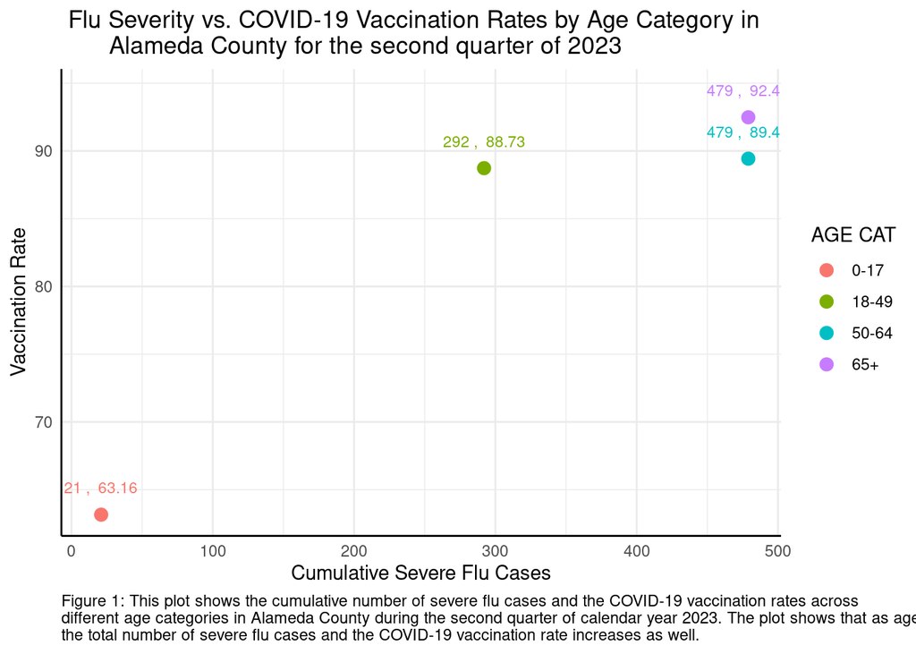

## Discussion

### **Relationship Between Age, Flu Severity, and Vaccination Rates**

The insights gleaned from the analysis of flu cases and COVID-19 vaccination data in Alameda County during the second quarter of calendar year 2023 carry important implications for future public health initiatives. The positive correlation between age and COVID-19 vaccination rates suggests a successful prioritization of older demographics. This finding aligns with existing knowledge on the heightened susceptibility of elderly individuals to severe respiratory infections, paving the way for targeted vaccination campaigns in these age groups. However, the persistence of unvaccinated individuals, particularly in younger categories, calls for continued outreach efforts to address potential vaccine hesitancy. The vulnerability of older populations to severe flu cases emphasizes the ongoing importance of vaccination efforts for this demographic. Looking forward, public health interventions should be adaptive, consider age-specific nuances, and leverage data to refine strategies. These findings contribute to the groundwork for preparing healthcare systems for seasonal variations in infectious diseases prevalence/incidence and underscore the need for research into age-related health disparities, ensuring that future interventions are both effective and equitable.